# Graficando mapas

17/07, 2020

## Cargamos paquetes

```r
library(ggforce)
library(scales)
library(raster)
library(rworldxtra)
library(sf)
library(tidyverse)
```

## Polígonos

## Partimos con un gráfico básico

```r
# Base de datos
githubURL <- ("https://raw.githubusercontent.com/derek-corcoran-barrios/derek-corcoran-barrios.github.io/master/Presentaciones_Espacial/Casos_Activos_Valpo.rds")
# La descargamos
download.file(githubURL, "Casos_Activos_Valpo.rds")
# La leemos
Casos_Activos_Valpo <- readRDS("Casos_Activos_Valpo.rds")
# Gráfico simple
ggplot() + geom_sf(data = Casos_Activos_Valpo, aes(fill = Activos_por_100.000)) +
    facet_wrap(~Fecha)
```

## Partimos con un gráfico básico (cont.)

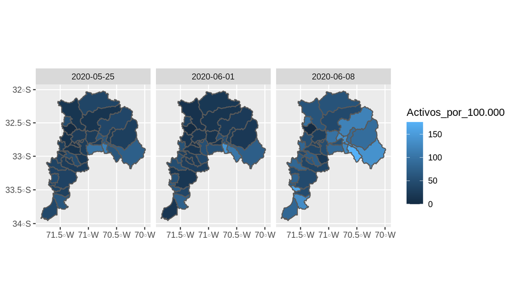

## Modifiquemos la escala

- Experimentemos con el número de colores

```r
ggplot() + geom_sf(data = Casos_Activos_Valpo, aes(fill = Activos_por_100.000)) +
    facet_wrap(~Fecha) + scale_fill_gradientn(name = "Activos por 100.000 hab",
    colours = heat.colors(10))
```

## Modifiquemos la escala (cont)

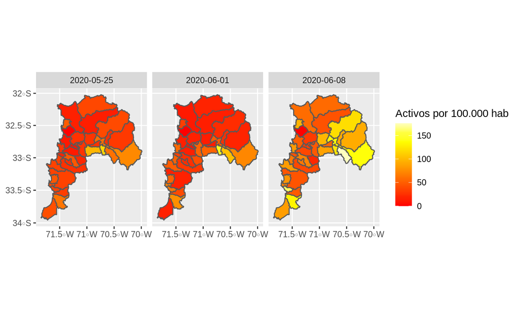

## Otras paletas

- rainbow
- terrain.colors
- topo.colors
- cm.colors

Ejemplo feo

```r
ggplot() + geom_sf(data = Casos_Activos_Valpo, aes(fill = Activos_por_100.000)) +
    facet_wrap(~Fecha) + scale_fill_gradientn(name = "Activos por 100.000 hab",
    colours = rainbow(10))
```

## Cuando es feo se nota por que es importante

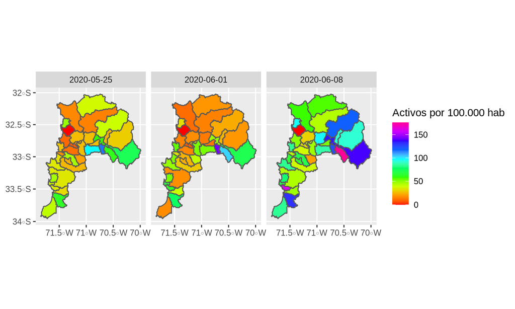

## Virids

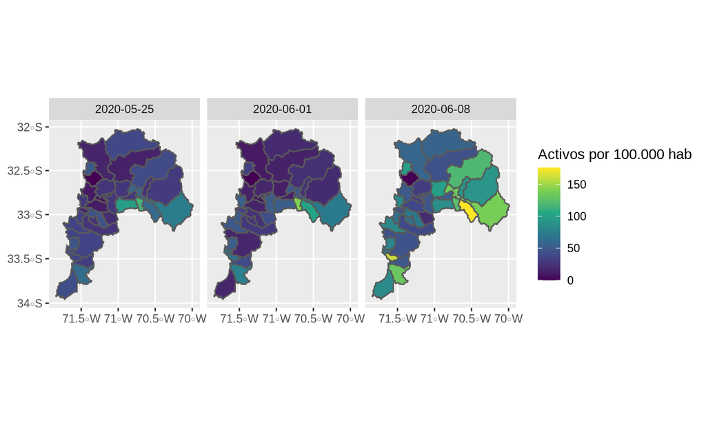

```r
ggplot() + geom_sf(data = Casos_Activos_Valpo, aes(fill = Activos_por_100.000)) +
    facet_wrap(~Fecha) + scale_fill_viridis_c(name = "Activos por 100.000 hab")
```

## Escala por bins

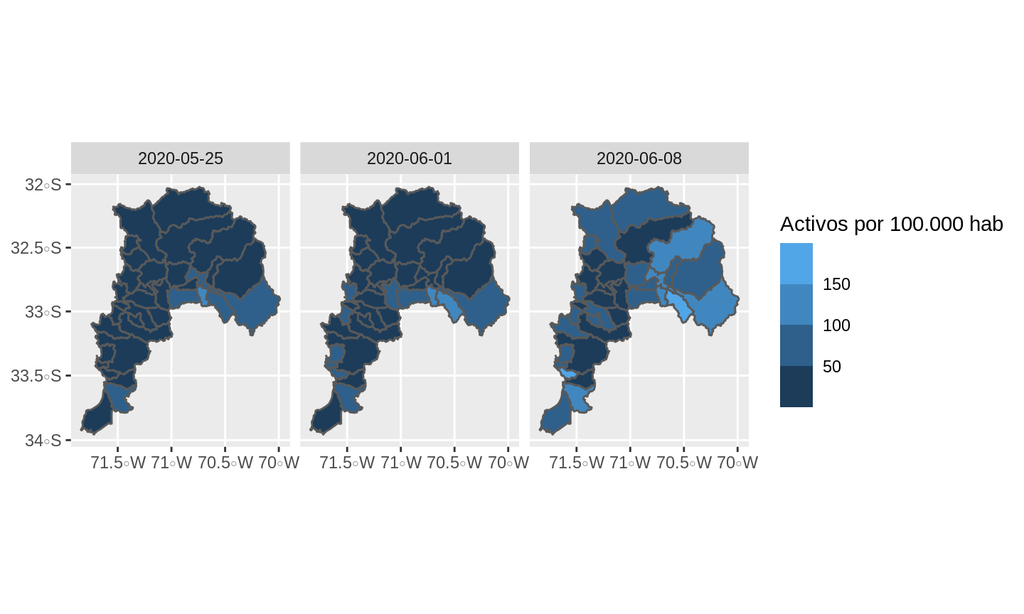

```r
ggplot() + geom_sf(data = Casos_Activos_Valpo, aes(fill = Activos_por_100.000)) +
    facet_wrap(~Fecha) + scale_fill_binned(name = "Activos por 100.000 hab")
```

## Cambiando algunos default

- breaks: donde se cortan los bins

```r
ggplot() + geom_sf(data = Casos_Activos_Valpo, aes(fill = Activos_por_100.000)) +
    facet_wrap(~Fecha) + scale_fill_binned(name = "Activos por 100.000 hab",
    breaks = seq(0, 200, by = 25))
```

[output not shown]

## Escala gradient2

- Algunos parametros importantes
  - mid = color de punto medio
  - high = color de valor alto
  - low = color de valor bajo
  - mipoint = que valor se considera medio

```r
ggplot() + geom_sf(data = Casos_Activos_Valpo, aes(fill = Activos_por_100.000)) +
    facet_wrap(~Fecha) + scale_fill_gradient2(mid = "white",
    low = muted("blue"), high = muted("red"), midpoint = median(Casos_Activos_Valpo$Activos_por_100.000),
    name = "Activos por 100.000 hab")
```

## Escala gradient2

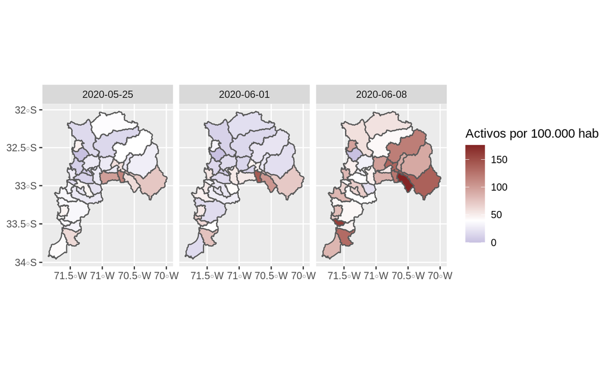

## últimos toques

- Punto de referencia del MINSAL 40 por cada 100.000 (midpoint)
- Agregamos titulo, subtitulo y fuente al pie
- Leyenda abajo
- lineas mas tenues

```r
ggplot() + geom_sf(data = Casos_Activos_Valpo, size = 0.05, aes(fill = Activos_por_100.000)) +
    facet_wrap(~Fecha) + scale_fill_gradient2(mid = "white",
    low = muted("blue"), high = muted("red"), midpoint = 40,
    name = "Activos por 100.000 hab") + theme(legend.position = "bottom") +
    labs(title = "Prevalencia de Región de Valparaíso por Provincia",
        subtitle = paste("Actualizado", max(CasosActivosCurso$Fecha)),
        caption = "Datos: https://github.com/MinCiencia/Datos-COVID19",
        y = NULL, x = NULL)
```

## Mapa final

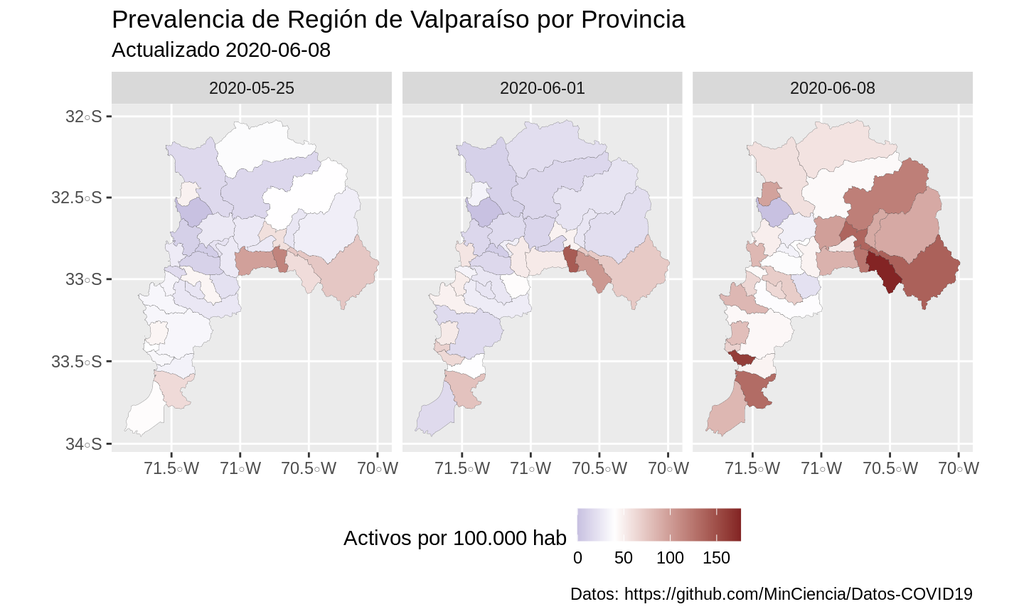

## Puntos

## Bajaremos puntos desde la biblioteca naciona

- Mapas [vectoriales de Chile](https://www.bcn.cl/siit/mapas_vectoriales/index_html)
- Ciudades y mas

```r
# Bajamos el archivo
download.file("https://www.bcn.cl/obtienearchivo?id=repositorio/10221/10400/2/Toponimos.zip",
    destfile = "Topo.zip")
# Lo descomprimimos
unzip("Topo.zip")
## Leemos el shapefile y nos quedamos solo con valparaíso
## continenal
Topo <- read_sf("Toponimos.shp") %>% dplyr::filter(Region ==
    "DE VALPARAISO") %>% st_crop(Casos_Activos_Valpo)
```

```
## [1] TRUE
```

```
## [1] TRUE TRUE TRUE TRUE TRUE TRUE TRUE TRUE
```

## Partamos con el mapa anterior de base:

```r
Mapa <- ggplot() + geom_sf(data = Casos_Activos_Valpo, size = 0.05,
    aes(fill = Activos_por_100.000)) + facet_wrap(~Fecha) + scale_fill_gradient2(mid = "white",
    low = muted("blue"), high = muted("red"), midpoint = 40,
    name = "Activos por 100.000 hab") + theme(legend.position = "bottom") +
    labs(title = "Prevalencia de Región de Valparaíso por Provincia",
        subtitle = paste("Actualizado", max(Casos_Activos_Valpo$Fecha)),
        caption = "Datos: https://github.com/MinCiencia/Datos-COVID19",
        y = NULL, x = NULL)
```

## Agreguemos los puntos

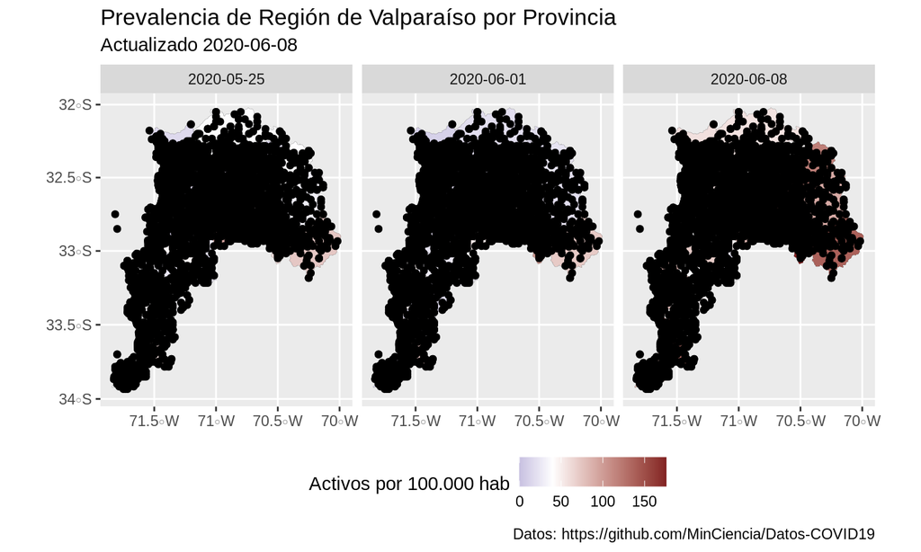

```r
Mapa + geom_sf(data = Topo)
```

## Quitemos puntos

```r
Topo2 <- Topo %>% dplyr::filter(Clase_Topo %in% c("Centro Poblado"))
Topo$Clase_Topo %>% unique()
```

```
##  [1] "Localidad Rural"
##  [2] "Localidad o Area"
##  [3] "Red Hidrografica"
##  [4] "Elementos del Relieve"
##  [5] "Centro Poblado"
##  [6] "Recinto Minero"
##  [7] "Infraestructura Ferroviaria"
##  [8] "Comuna"
##  [9] "Atributo Puntual"
## [10] "Entidades y Campamentos"
## [11] "Termas y Baños"
## [12] "Calles. Carreteras, Caminos o Via Fe"
## [13] "Obras de Infraestructura"
## [14] "Vegetacion"
```

## Sigue siendo mucho

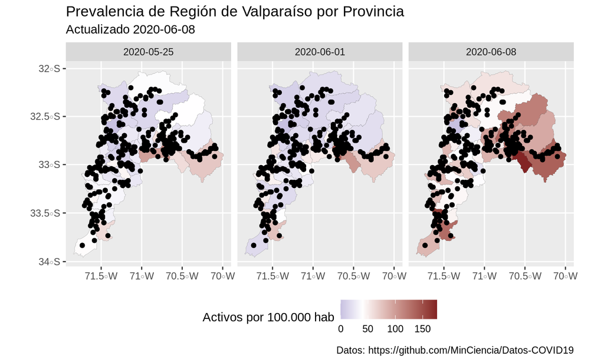

```r
Mapa + geom_sf(data = Topo2)
```

## Dejemos solo las capitales provinciales

```r
Topo2 <- Topo %>% dplyr::filter(Nombre %in% c("Los Andes", "Quilpué",
    "La Ligua", "Quillota", "San Antonio", "San Felipe", "Valparaíso"),
    Clase_Topo %in% c("Centro Poblado"))
```

## Mejor!!

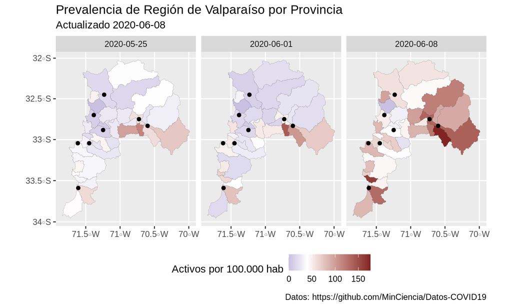

```r
Mapa + geom_sf(data = Topo2)
```

## Agreguemos los nombres

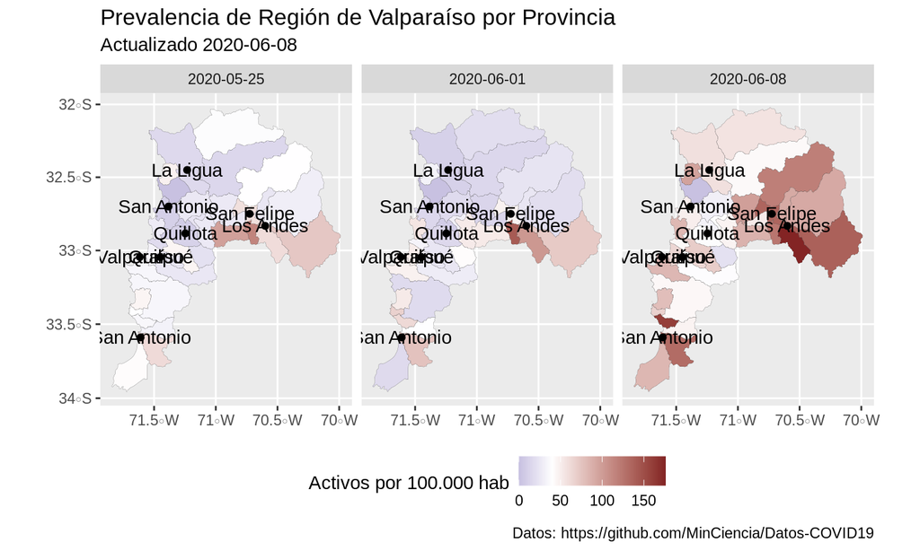

```r
Mapa + geom_sf(data = Topo2) + geom_sf_text(data = Topo2, aes(label = Nombre))
```

## Problemas

- Tapan los puntos y chocan los nombres
- ggrepel
- cambio de tema

```r
Mapa + geom_sf(data = Topo2) + ggrepel::geom_text_repel(data = Topo2,
    aes(label = Nombre, geometry = geometry), stat = "sf_coordinates",
    force = 1) + theme_bw()
```

## Listos?

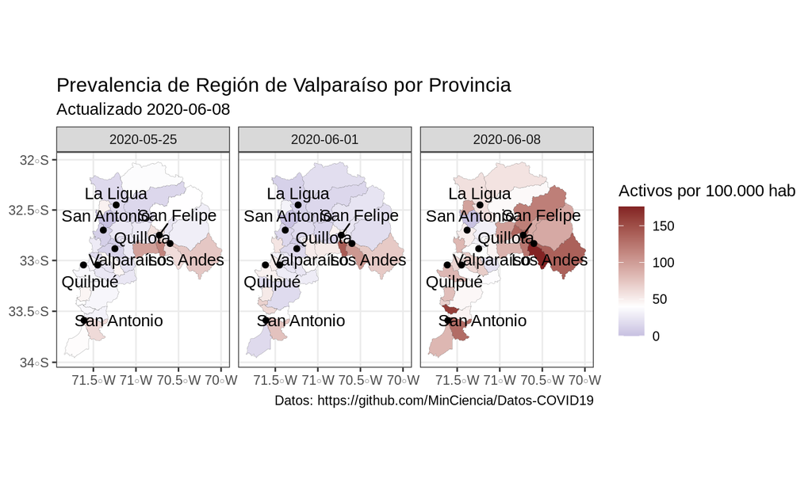

## Exportando archivos

## Usando tif

```r
tiff("Mapa.tiff", units = "in", width = 10, height = 5, res = 600,
    compression = "lzw")
Mapa + geom_sf(data = Topo2) + ggrepel::geom_text_repel(data = Topo2,
    aes(label = Nombre, geometry = geometry), stat = "sf_coordinates",
    force = 1) + theme_bw()
dev.off()
```

- Se puede usar bmp, jpeg, png, svg, cairo_pdf

```
## [1] TRUE
```

## Rasters

## Prioridades de conservación en el neotrópico

- De este [paper](https://onlinelibrary.wiley.com/doi/full/10.1111/ecog.05166)
- De [acá](https://figshare.com/collections/Hannah_et_al_2020_Ecography/4868019) pueden bajarlo para otros continentes

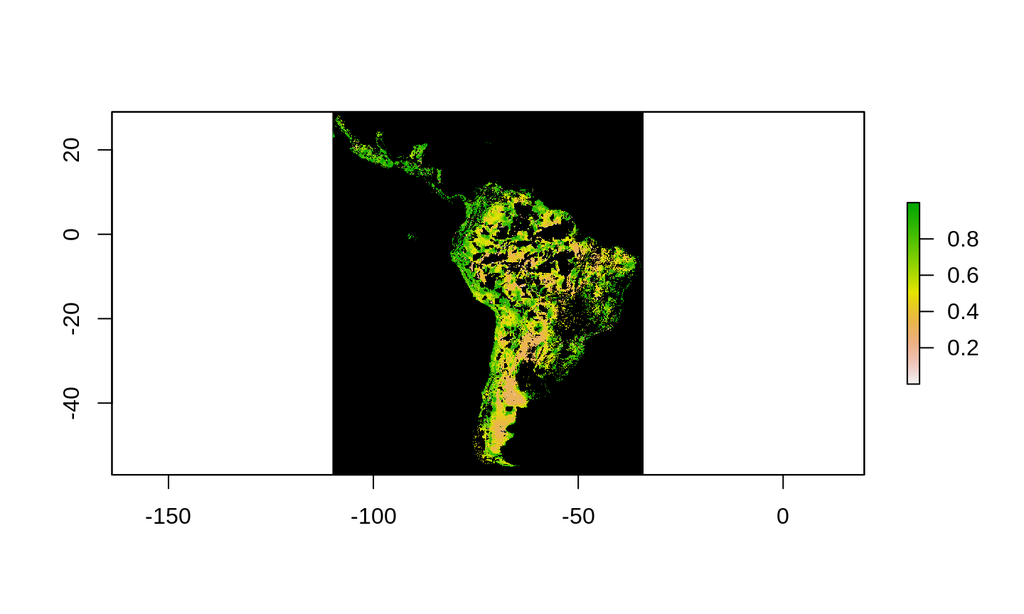

```r
download.file("https://ndownloader.figshare.com/files/21843771",
    destfile = "Priority.tiff")
Priority <- raster("Priority.tiff")
plot(Priority, colNA = "black")
```

```r
Priority <- readAll(Priority)
file.remove("Priority.tiff")
```

```
## [1] TRUE
```

## Poligono para el mismo lugar

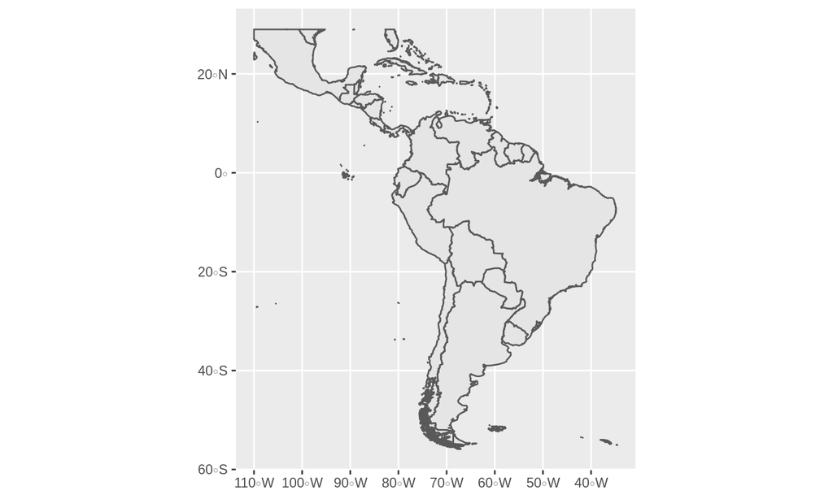

```r
data("countriesHigh")
SA <- countriesHigh %>% st_as_sf() %>% st_make_valid() %>% st_crop(extent(Priority))
ggplot() + geom_sf(data = SA)
```

## Cambiando Priority

```r
## Cambiamos los NA a 0
values(Priority) <- ifelse(is.na(values(Priority)), 0, values(Priority))
## Generamos un raster de todo el neotropico con valores de 1
MASK <- rasterize(SA, Priority, field = 1)
## Multiplicamos para dejar 0s e prioridad
Priority <- Priority * MASK
## Achicamos el extent
Priority <- raster::trim(Priority)
```

## Transformamos las prioridades en categorías

```r
Priority2 <- Priority %>% as("SpatialPixelsDataFrame") %>% as.data.frame() %>%
    rename(Priority = layer) %>% mutate(Priority = case_when(Priority >=
    0.97 ~ "Prioridad muy alta", Priority < 1 & Priority > 0.87 ~
    "Prioridad alta", Priority == 0 ~ "Altamente desarrollado")) %>%
    dplyr::filter(!is.na(Priority)) %>% mutate(Priority = fct_relevel(Priority,
    "Prioridad alta", "Prioridad muy alta"))
P <- ggplot() + geom_sf(data = SA, size = 0.1) + geom_raster(data = Priority2,
    aes(x = x, y = y, fill = Priority))
```

## Veamos que tal

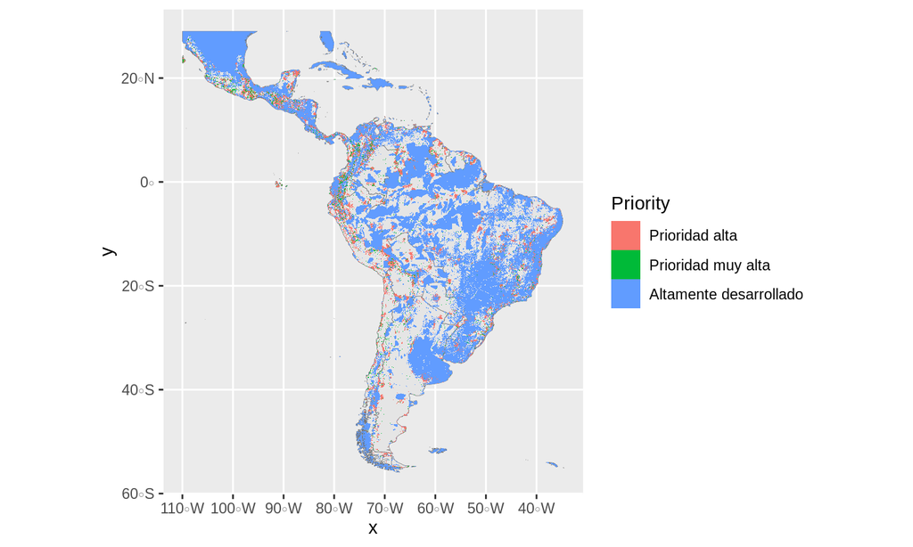

## Mejoremos los colores

```r
P <- P + scale_fill_manual(name = "Priority", values = c("#006d2c",
    "#31a354", "#d7c29e"))
```

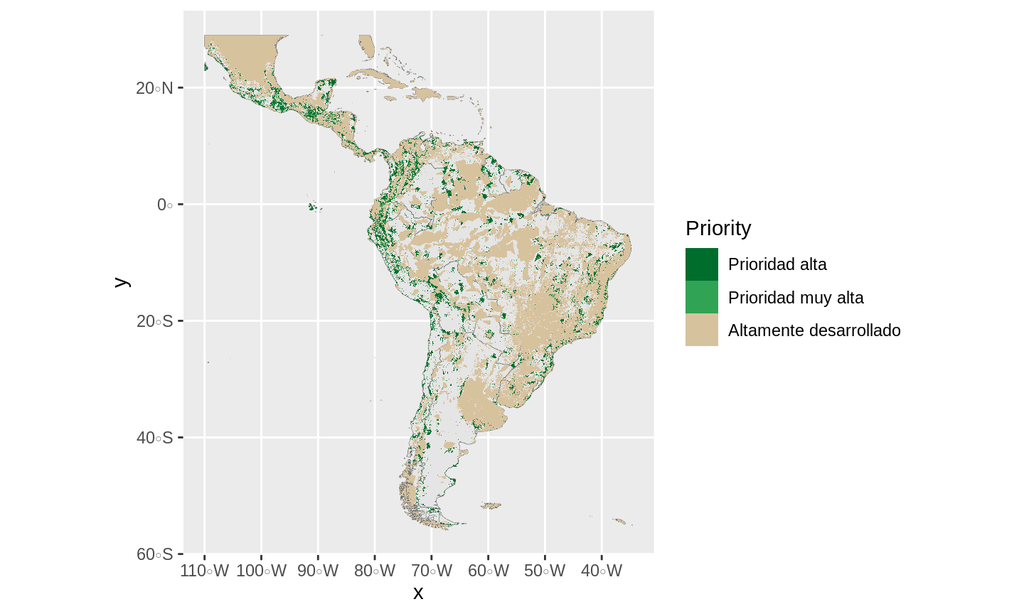

## Avancemos más

```r
P <- P + ylab("") + xlab("") + theme_bw()
```

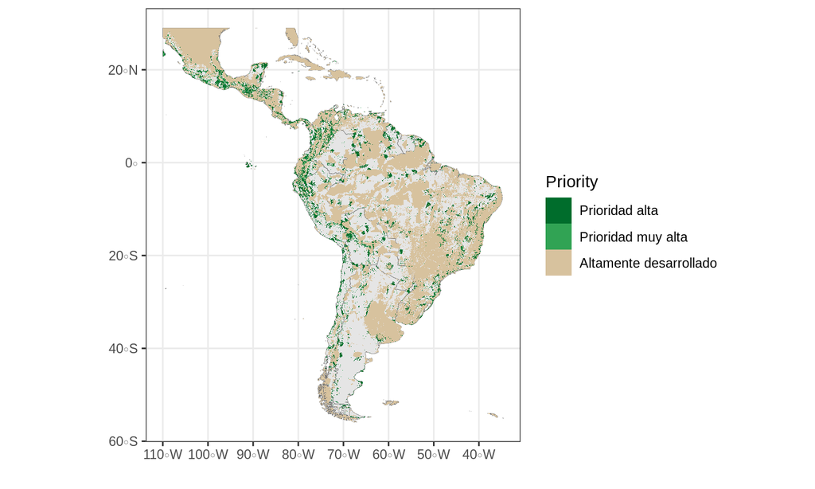

## Inset map

```r
P <- P + facet_zoom(xlim = c(-87.117, -82.56), ylim = c(5.51,
    11.21), horizontal = T, zoom.size = 0.8, shrink = F)
```

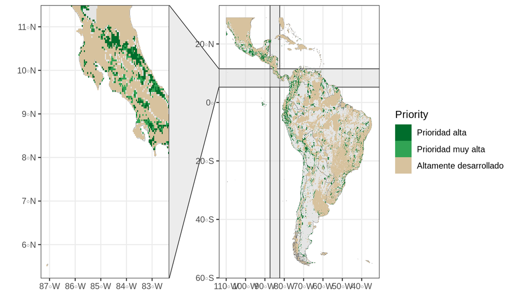

## Exportamos

```r
tiff("Priority.tiff", units = "in", width = 10, height = 8, res = 600,
    compression = "lzw")
P
dev.off()
```